# Project: No-show appointments - [KaggleV2-May-2016]

```python
df_yes['ScheduledDay'].value_counts()
```

```
2016-04-25 17:17:46+00:00    21
2016-04-25 17:18:27+00:00    20
2016-05-06 07:09:53+00:00    16
2016-04-25 17:17:23+00:00    16
2016-05-31 09:54:52+00:00    14
                             ..
2016-05-19 09:26:21+00:00     1
2016-05-03 13:29:58+00:00     1
2016-05-05 09:28:58+00:00     1
2016-05-24 10:23:32+00:00     1
2016-05-03 09:15:25+00:00     1
Name: ScheduledDay, Length: 21180, dtype: int64
```

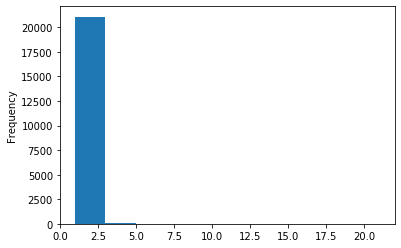

```python
ind = df_yes['ScheduledDay'].value_counts().index
df_yes['ScheduledDay'].value_counts()[ind].plot(kind = 'hist');
```

```python
df_no['ScheduledDay'].value_counts()
```

```
2016-03-29 10:44:23+00:00    11
2016-03-29 10:43:41+00:00    10
2016-05-25 09:36:45+00:00     9
2016-06-03 13:13:04+00:00     9
2016-05-09 15:52:40+00:00     9
                             ..
2016-05-12 09:09:57+00:00     1
2016-06-08 13:27:45+00:00     1
2016-05-13 09:36:41+00:00     1
2016-06-01 11:01:09+00:00     1
2016-05-04 09:41:05+00:00     1
Name: ScheduledDay, Length: 83708, dtype: int64
```

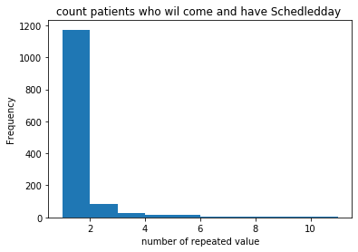

```python
df_no['ScheduledDay'].value_counts()[ind].plot(kind = 'hist');
plt.xlabel('number of repeated value')
plt.title('count patients who wil come and have Schedledday ');
```

this is a histogram that describe number of repeated value for patients who will come and have Schedledday

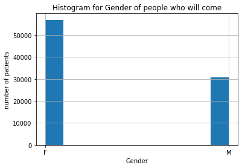

```python
df_no.Gender.hist();
plt.ylabel('number of patients')
plt.xlabel('Gender')
plt.title('Histogram for Gender of people who will come');
```

this is a histogram that describe number of gender for patients who will come

```python
df_no.Gender.describe()
```

```
count     87794
unique        2
top           F
freq      56962
Name: Gender, dtype: object
```

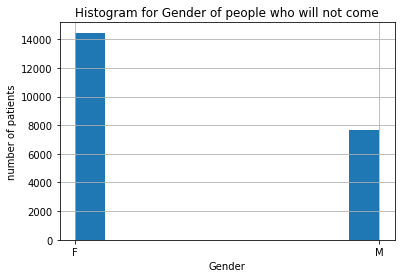

```python
df_yes.Gender.hist();
plt.ylabel('number of patients')
plt.xlabel('Gender')
plt.title('Histogram for Gender of people who will not come');
```

this is a histogram that describe number of gender for patients who will not come

```python
df_yes.Gender.describe()
```

```
count     22098
unique        2
top           F
freq      14455
Name: Gender, dtype: object
```

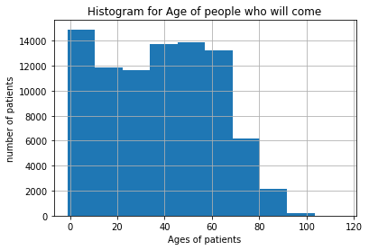

```python
df_no.Age.hist();
plt.ylabel('number of patients')
plt.xlabel('Ages of patients')
plt.title('Histogram for Age of people who will come');
```

this is a histogram that describe Ages for patients who will come

```python
df_no.Age.describe()
```

```
count    87794.000000
mean        37.795681
std         23.350062
min         -1.000000
25%         18.000000
50%         38.000000
75%         56.000000
max        115.000000
Name: Age, dtype: float64
```

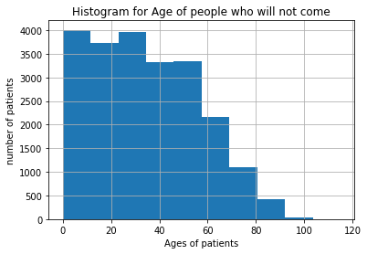

```python
df_yes.Age.hist();
plt.ylabel('number of patients')
plt.xlabel('Ages of patients')
plt.title('Histogram for Age of people who will not come');
```

this is a histogram that describe Ages for patients who will not come

```python
df_yes.Age.describe()
```

```
count    22098.000000
mean        34.283917
std         21.965982
min          0.000000
25%         16.000000
50%         33.000000
75%         51.000000
max        115.000000
Name: Age, dtype: float64
```

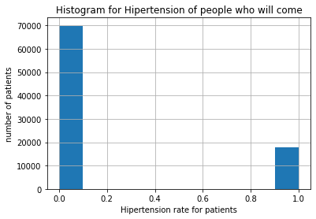

```python
df_no.Hipertension.hist();
plt.ylabel('number of patients')
plt.xlabel('Hipertension rate for patients')
plt.title('Histogram for Hipertension of people who will come');
```

this is a histogram that describe number of patients who will come and have Hipertensions

```python
df_no.Hipertension.describe()
```

```
count    87794.000000
mean         0.204433
std          0.403289
min          0.000000
25%          0.000000
50%          0.000000
75%          0.000000
max          1.000000
Name: Hipertension, dtype: float64
```

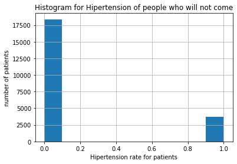

```python
df_yes.Hipertension.hist();
plt.ylabel('number of patients')
plt.xlabel('Hipertension rate for patients')
plt.title('Histogram for Hipertension of people who will not come');
```

this is a histogram that describe number of patients who will not come and have hipertensions

```python
df_yes.Hipertension.describe()
```

```
count    22098.000000
mean         0.168703
std          0.374498
min          0.000000
25%          0.000000
50%          0.000000
75%          0.000000
max          1.000000
Name: Hipertension, dtype: float64
```

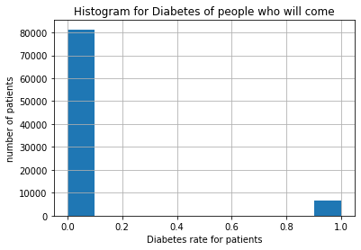

```python
df_no.Diabetes.hist();
plt.ylabel('number of patients')
plt.xlabel('Diabetes rate for patients')
plt.title('Histogram for Diabetes of people who will come');
```

this is a histogram that describe number of patients who will come and have Diabetes

```python
df_no.Diabetes.describe()
```

```
count    87794.000000
mean         0.073707
std          0.261294
min          0.000000
25%          0.000000
50%          0.000000
75%          0.000000
max          1.000000
Name: Diabetes, dtype: float64
```

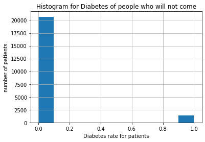

```python
df_yes.Diabetes.hist();
plt.ylabel('number of patients')
plt.xlabel('Diabetes rate for patients')
plt.title('Histogram for Diabetes of people who will not come');
```

this is a histogram that describe number of patients who will not come and have Diabetes

```python
df_yes.Diabetes.describe()
```

```
count    22098.00000
mean         0.06435
std          0.24538
min          0.00000
25%          0.00000
50%          0.00000
75%          0.00000
max          1.00000
Name: Diabetes, dtype: float64
```

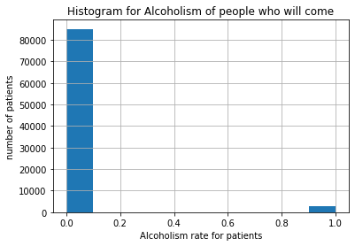

```python
df_no.Alcoholism.hist();
plt.ylabel('number of patients')
plt.xlabel('Alcoholism rate for patients')
plt.title('Histogram for Alcoholism of people who will come');
```

this is a histogram that describe number of patients who will come and drink Alcohol

```python
df_no.Alcoholism.describe()
```

```
count    87794.000000
mean         0.030480
std          0.171906
min          0.000000
25%          0.000000
50%          0.000000
75%          0.000000
max          1.000000
Name: Alcoholism, dtype: float64
```

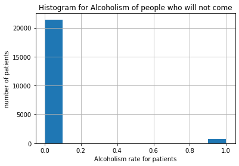

```python
df_yes.Alcoholism.hist();
plt.ylabel('number of patients')
plt.xlabel('Alcoholism rate for patients')
plt.title('Histogram for Alcoholism of people who will not come');
```

this is a histogram that describe number of patients who will not come and drink Alcohol

```python
df_yes.Alcoholism.describe()
```

```
count    22098.000000
mean         0.030229
std          0.171221
min          0.000000
25%          0.000000
50%          0.000000
75%          0.000000
max          1.000000
Name: Alcoholism, dtype: float64
```

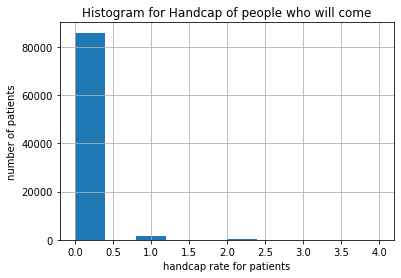

```python
df_no.Handcap.hist();
plt.ylabel('number of patients')
plt.xlabel('handcap rate for patients')
plt.title('Histogram for Handcap of people who will come');
```

this is a histogram that describe number of patients who will come and have Handcap

```python
df_no.Handcap.describe()
```

```
count    87794.000000
mean         0.022633
std          0.162000
min          0.000000
25%          0.000000
50%          0.000000
75%          0.000000
max          4.000000
Name: Handcap, dtype: float64
```

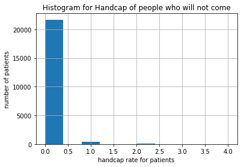

```python
df_yes.Handcap.hist();
plt.ylabel('number of patients')
plt.xlabel('handcap rate for patients')
plt.title('Histogram for Handcap of people who will not come');
```

this is a histogram that describe number of patients who will not come and have Handcap

```python
df_yes.Handcap.describe()
```

```
count    22098.000000
mean         0.020138
std          0.156331
min          0.000000
25%          0.000000
50%          0.000000
75%          0.000000
max          4.000000
Name: Handcap, dtype: float64
```

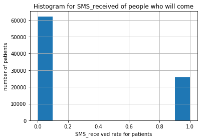

```python
df_no.SMS_received.hist();
plt.ylabel('number of patients')
plt.xlabel('SMS_received rate for patients')
plt.title('Histogram for SMS_received of people who will come');
```

this is a histogram that describe number of patients who will come and have SMS_recieved

```python
df_no.SMS_received.describe()
```

```
count    87794.000000
mean         0.292708
std          0.455008
min          0.000000
25%          0.000000
50%          0.000000
75%          1.000000
max          1.000000
Name: SMS_received, dtype: float64
```

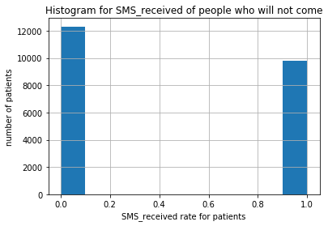

```python
df_yes.SMS_received.hist();
plt.ylabel('number of patients')
plt.xlabel('SMS_received rate for patients')
plt.title('Histogram for SMS_received of people who will not come');
```

this is a histogram that describe number of patients who will not come and have SMS_recieved

```python
df_yes.SMS_received.describe()
```

```
count    22098.000000
mean         0.442755
std          0.496723
min          0.000000
25%          0.000000
50%          0.000000
75%          1.000000
max          1.000000
Name: SMS_received, dtype: float64
```

```python
df_no.mean()
```

```
Age             37.795681
Scholarship      0.093913
Hipertension     0.204433
Diabetes         0.073707
Alcoholism       0.030480
Handcap          0.022633
SMS_received     0.292708
dtype: float64
```

```python
df_yes.mean()
```

```
Age             34.283917
Scholarship      0.115667
Hipertension     0.168703
Diabetes         0.064350
Alcoholism       0.030229
Handcap          0.020138
SMS_received     0.442755
dtype: float64
```

## Conclusions

> **results**: Our data suggest that
> 1. There is not big difference between the distribution of Age between patients who showed up for the appointment versus the patients that did not show up for the appointment.
> 2. There is a higher percentage of people that received an SMS and did not show up when compared to people who received an SMS and did show up.
> 3. People that have a disease are 3% more likely to show up for the appointment than people who do not have a disease
> 4. Handicap patients specifically.however, are more likely to show up to the appointment compared to people who are not Handicap.
> 5. Being enrolled in the Scholarship progranm does not seem to make peopie more likely to show up to the appointment.

## Submitting your Project

> **Tip**: Before you submit your project, you need to create a .html or .pdf version of this notebook in the workspace here. To do that, run the code cell below. If it worked correctly, you should get a return code of 0, and you should see the generated .html file in the workspace directory (click on the orange Jupyter icon in the upper left).

> **Tip**: Alternatively, you can download this report as .html via the **File** > **Download as** submenu, and then manually upload it into the workspace directory by clicking on the orange Jupyter icon in the upper left, then using the Upload button.

> **Tip**: Once you've done this, you can submit your project by clicking on the "Submit Project" button in the lower right here. This will create and submit a zip file with this .ipynb doc and the .html or .pdf version you created. Congratulations!

```python
from subprocess import call
call(['python', '-m', 'nbconvert', 'No_show.ipynb'])
```

```
0
```